# Museums per capita

> Here's a nice random fact for you: NZ has a high number of museums per capita. 2013 was 1:9,500.  
> Same year, UK was 1:17,000, the US 1:24,000. 2008 Australia was 1:18,000.  
> ~55,000 museums globally, approx one for every 146,000 people. NZ is well ahead of the bell curve!

> — Scott Pilkington (@spil030) [March 24, 2019](https://twitter.com/spil030/status/1109732472240009217?ref_src=twsrc%5Etfw)

```r
library(tidyverse)
library(rvest)
library(gapminder)
```

# Getting some comparison countries

I decided to grab some countries with populations within a million of New Zealands. The easiest dataset I new with loads of population data is in the lovely `gapminder` package. Unfortunately the most recent population counts are for 2007, but this attempt is so back-of-the-envelope anyway, and more just a chance to play, so I’m going to just go with that. Also provides GDP per capita which I think is interesting for arts and culture funding.

```r
my_pop = gapminder %>%
  filter(year == max(year)) %>%
  mutate(NZpop = ifelse(country == "New Zealand", pop, NA)) %>%
  mutate(NZpop = as.numeric(NZpop)) %>%
  arrange(NZpop) %>%
  fill(NZpop) %>%
  mutate(`Difference from NZ` = pop-NZpop) %>%
  filter(abs(`Difference from NZ`) < 1000000)
```

# Examples of getting number of museums from Wikipedia lists

Below are a couple very messy examples of scraping the individual pages on Wikipedia:

```r
NZ = read_html("https://en.wikipedia.org/wiki/List_of_museums_in_New_Zealand") %>%
  html_nodes("ul") %>%
  html_text() %>%
  as.data.frame() %>%
  .[3:22,] %>%
  as.data.frame() %>%
  rename(name = 1) %>%
  separate_rows(name, sep = "\\\n")

nrow(NZ)
```

```
## [1] 138
```

```r
ireland = read_html("https://en.wikipedia.org/wiki/List_of_museums_in_the_Republic_of_Ireland") %>%
  html_nodes("table") %>%
  .[[2]] %>%
  html_table(fill = TRUE)

nrow(ireland)
```

```
## [1] 244
```

```r
norway = read_html("https://en.wikipedia.org/wiki/List_of_museums_in_Norway") %>%
  html_nodes("ul") %>%
  html_text() %>%
  as.data.frame() %>%
  .[3:22,] %>%
  data_frame() %>%
  rename(name = 1) %>%
  separate_rows(name, sep = "\\\n")
nrow(norway)
```

```
## [1] 150
```

```r
oman = read_html("https://en.wikipedia.org/wiki/List_of_museums_in_Oman") %>%
  html_nodes("ul") %>%
  html_text() %>%
  as.data.frame() %>%
  .[1,] %>%
  data_frame() %>%
  rename(name = 1) %>%
  separate_rows(name, sep = "\\\n")
nrow(oman)
```

```
## [1] 11
```

```r
panama = read_html("https://en.wikipedia.org/wiki/List_of_museums_in_Panama") %>%
  html_nodes("table") %>%
  .[[1]] %>%
  html_table(fill = TRUE)
nrow(panama)
```

```
## [1] 20
```

```r
puertorico = read_html("https://en.wikipedia.org/wiki/List_of_museums_in_Puerto_Rico") %>%
  html_nodes("table") %>%
  .[[2]] %>%
  html_table(fill = TRUE)
nrow(puertorico)
```

```
## [1] 82
```

```r
singapore = read_html("https://en.wikipedia.org/wiki/List_of_museums_in_Singapore") %>%
  html_nodes("ul") %>%
  html_text() %>%
  as.data.frame() %>%
  .[2:4,] %>%
  data_frame() %>%
  rename(name = 1) %>%
  separate_rows(name, sep = "\\\n")
nrow(singapore)
```

```
## [1] 42
```

```r
uruguay = read_html("https://en.wikipedia.org/wiki/List_of_museums_in_Uruguay") %>%
  html_nodes("ul") %>%
  html_text() %>%
  as.data.frame() %>%
  .[1,] %>%
  data_frame() %>%
  rename(name = 1) %>%
  separate_rows(name, sep = "\\\n")
nrow(uruguay)
```

```
## [1] 10
```

The ideal would be to use the [main page](https://en.wikipedia.org/wiki/List_of_museums_by_country) to get all the hyperlinks with something like this:

```r
get_links = read_html("https://en.wikipedia.org/wiki/List_of_museums_by_country") %>%
  html_nodes("a") %>%
  html_attr("href") %>%
  data.frame() %>%
  rename(links = 1) %>%
  filter(grepl("wiki/List_of_museums_in", links)) %>%
  mutate(links = paste0("https://en.wikipedia.org/", links))
```

…and then scrape each of these, but aside from there being several ways these pages are formatted, you also have some lists just under the country title, not linking to a new page, and then you have some missing (I think Republic of Congo’s list of museums is missing from this main page). Ugh.

# Making a graph

So here is a quick look at the number of museums per 100,000 people. There are quite a few limitations on the data of course, but interesting none the less, I hope.

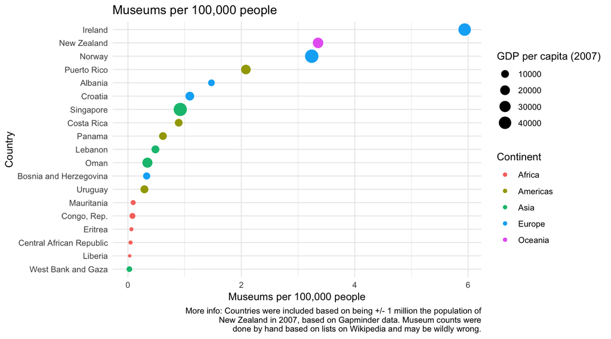

```r
# numbers mostly by hand from wikipedia

museums = read_csv("museums.csv")

tidy_museums = museums %>%
  mutate(`Museums per 100,000` = `N museums from Wikipedia`/pop*100000) %>%
  filter(!is.na(country))

tidy_museums %>%
  mutate(country = fct_reorder(country, `Museums per 100,000`)) %>%
  ggplot(aes(x = `Museums per 100,000`, y = country, size = gdpPerCap, color = continent)) +
  geom_point() +
  scale_size_continuous(name = "GDP per capita (2007)") +
  scale_color_discrete(name = "Continent") +
  ylab(label = "Country") +
  xlab(label = "Museums per 100,000 people") +
  theme_minimal() +
  ggtitle("Museums per 100,000 people") +
  labs(caption = "More info: Countries were included based on being +/- 1 million the population of\nNew Zealand in 2007, based on Gapminder data. Museum counts were\ndone by hand based on lists on Wikipedia and may be wildly wrong.")
```

Code and data available at https://github.com/elb0/museums-per-capita.